# Module 8: TREE-BASED METHODS

TMA4268 Statistical Learning V2019

Mette Langaas and Thea Roksvåg, Department of Mathematical Sciences, NTNU

week 10 2019

Last changes: (13.03: typos on stopping trees, 04.03: wrong ozone data, 03.03: broken links, example error, 25.02: first version)

# Introduction

## Learning material for this module

- James et al (2013): An Introduction to Statistical Learning. Chapter 8.
- [Classnotes 04.03.2019](https://www.math.ntnu.no/emner/TMA4268/2019v/notes/M8L1notes.pdf)
- [Classnotes 07.03.2019](https://www.math.ntnu.no/emner/TMA4268/2019v/notes/M8L2notes.pdf)

Some of the figures in this presentation are taken (or are inspired) from “An Introduction to Statistical Learning, with applications in R” (Springer, 2013) with permission from the authors: G. James, D. Witten, T. Hastie and R. Tibshirani.

## What will you learn?

- Decision tree - idea and example
- Regression trees - how to grow
- Classification trees - any changes to the above
- Pruning a tree
- Bagging, with variable importance plots
- Random forests
- Boosting

## Running example: Detection of Minor Head Injury

Remark: this data is artificial.

Assume that you work as a statistician at a hospital, and the head of department asks you to develop a

*simple method for detecting whether a patient is at risk for having a minor head injury*.

The method should be easy to

- interpret for the medical personell that are not skilled in statistics, and
- the method should be fast, such that the medical personell quickly can identify a patient that needs treatment.
- The variable *clinically.important.brain.injury* will be the response of our model: It has value 1 if a person has an acute brain injury, and 0 otherwise.
- In this dataset, 250 (19%) of the patients have a clinically important brain injury.
- 10 variables are used as explanatory variables. These variables describe the state of the patient:
  - Is he/she vomiting?
  - Is the Glasgow Coma Scale (GCS) score after 2 hours equal to 15 (or not)?
  - Has he/she an open scull fracture?
  - Has he/she had a loss of consciousness?
  - and so on.

Comment on GCS: the scale goes back to an article in the Lancet in 1974, and is used to describe the level of consciousness of patients with an acute brain injury. Read more? https://www.glasgowcomascale.org/what-is-gcs/

These are questions the medical staff ask themselves when diagnosing the patient. Our job as a statistician is to systemize these questions in a good way so we can use them to estimate the probability of a brain injury.

This can be done by using tree-based methods.

The dataset includes data about 1321 patients and is a modified and smaller version of the (simulated) dataset *headInjury* from the *DAAG* library. We have made *age* instead of *age.65* giving us the “exact” age of the patient.

```
##    amnesia bskullf GCSdecr GCS.13 GCS.15 risk consc oskullf vomit
## 3        0       0       0      0      0    0     0       0     0
## 9        0       0       0      0      0    1     0       0     0
## 11       0       0       0      0      0    0     0       0     0
## 12       1       0       0      0      0    0     0       0     0
## 14       0       0       0      0      0    0     0       0     0
## 16       0       0       0      0      0    0     0       0     0
##    clinically.important.brain.injury age
## 3                                  0  44
## 9                                  0  67
## 11                                 0  62
## 12                                 0   1
## 14                                 0  55
## 16                                 0  63
```

## Main idea

The main idea behind tree-based methods is to

- derive a set of decision rules for segmenting the predictor space into a number of regions.
- In order to make a prediction for a new observation, we classify the observation into one of these regions by applying the derived decision rules.
- Then we typically use the mean or a majority vote of the training observations in this region as the prediction.

Below is a clasification tree made from a training set of 850 randomly drawn observations (training set) for the head injury example.

Observe: at splits criterion at node is to the left in the tree. So, root node has “GCS.15:0” so if “GCS.15=0” we go left, and if “GCS.15=1” we go right in the tree.

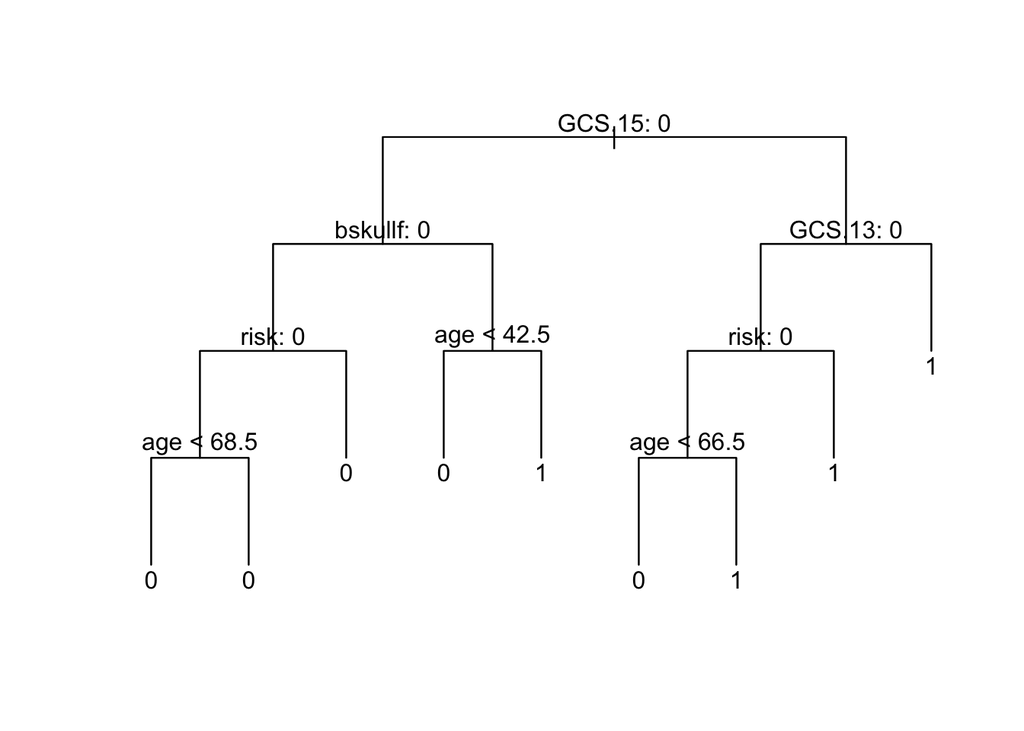

```
## node), split, n, deviance, yval, (yprob)
##       * denotes terminal node
##
##  1) root 850 819.00 0 ( 0.8129 0.1871 )
##    2) GCS.15: 0 711 520.00 0 ( 0.8805 0.1195 )
##      4) bskullf: 0 663 398.00 0 ( 0.9110 0.0890 )
##        8) risk: 0 487 203.00 0 ( 0.9466 0.0534 )
##         16) age < 68.5 445 131.00 0 ( 0.9663 0.0337 ) *
##         17) age > 68.5 42  48.30 0 ( 0.7381 0.2619 ) *
##        9) risk: 1 176 170.00 0 ( 0.8125 0.1875 ) *
##      5) bskullf: 1 48  66.20 1 ( 0.4583 0.5417 )
##       10) age < 42.5 13  11.20 0 ( 0.8462 0.1538 ) *
##       11) age > 42.5 35  43.60 1 ( 0.3143 0.6857 ) *
##    3) GCS.15: 1 139 192.00 1 ( 0.4676 0.5324 )
##      6) GCS.13: 0 121 167.00 0 ( 0.5289 0.4711 )
##       12) risk: 0 78 101.00 0 ( 0.6538 0.3462 )
##         24) age < 66.5 66  77.30 0 ( 0.7273 0.2727 ) *
##         25) age > 66.5 12  13.50 1 ( 0.2500 0.7500 ) *
##       13) risk: 1 43  52.70 1 ( 0.3023 0.6977 ) *
##      7) GCS.13: 1 18   7.72 1 ( 0.0556 0.9444 ) *
```

By using simple decision rules related to the most important explanatory variables the medical staff can now assess the probability of a brain injury.

- The advantage of such decisions trees is that they are easier to interpret than many of the classification (and regression) methods that we have studied so far
- and they provide an easy way to visualize the data for non-statisticians.

## Glossary

- Classification and regression trees are usually drawn upside down, where the top node is called the *root*.
- The *terminal nodes* or *leaf nodes* are the nodes at the bottom, with no splitting criteria. These represent the final predicted class (for classification trees) or predicted response value (for regression trees) and are written symbolically as $R_j$ for $j = 1, 2, ..., J$ - and will be referred to as *non-overlapping regions*.
- *Internal nodes* are all nodes between the root and the terminal nodes. These nodes correspond to the partitions of the predictor space.
- *Branches*: segment of the tree connecting the nodes.

We will consider only binary splits on one variable, but multiway splits and linear combination of variabes are possible - but not so common.

# Constructing a decision tree

You can construct decision trees for both classification and regression problems, first we focus on constructing a regression tree.

## Regression tree

Assume that we have a dataset consisting of $n$ pairs $({\bf x}_i,Y_i)$, $i=1,\ldots,n$, and each predictor is ${\bf x}_i=(x_{i1},x_{i2},...,x_{ip})$.

Two steps:

1. Divide the predictor space into non-overlapping regions $R_1,R_2,\ldots,R_J$.
2. For every observation that falls into region $R_j$ we make the same prediction - which is the mean of the responses for the training observations that fall into $R_j$.

How to divide the predictor space into non-overlapping regions $R_1,R_2,\ldots,R_J$?

We could try to minimize the RSS (residual sums of squares) on the training set given by
$$\text{RSS}=\sum_{j=1}^J \sum_{i \in R_j}(y_i-\hat{y}_{R_j})^2,$$
where $\hat{y}_{R_j}$ is the mean response for the training observations in region $j$. The mean $\hat{y}_{R_j}$ is also the predicted value for a new observations that falls into region $j$.

To do this we need to consider every partition of the predictor space, and compute the RSS for each partition. An exhaustive search over possible trees is *not* computationally feasible.

Ripley (1996, p 216): Two types of optimality. a) Optimality of the partitioning of the predictor space : only feasible for small dimensions. b) Given partitioning of predictor space, how to represent this by a tree in the best possible way (=minimal expected number of tests) is a NP-complete problem.

A *greedy* approach is taken (aka top-down) - called *recursive binary splitting.*

## Recursive binary splitting

We start at the top of the tree and divide the predictor space into two regions, $R_1$ and $R_2$ by making a decision rule for one of the predictors $x_1, x_2,...,x_p$. If we define the two regions by $R_1(j,s)=\{x|x_j<s\}$ and $R_2(j,s)=\{x|x_j\geq s\}$, it means that we need to find the (predictor) $j$ and (splitting point) $s$ that minimize

$$\sum_{i: x_i \in R_1(j,s)}(y_i-\hat{y}_{R_1})^2+\sum_{i: x_i \in R_2(j,s)}(y_i -\hat{y}_{R_2})^2,$$

where $\hat{y}_{R_1}$ and $\hat{y}_{R_2}$ are the mean responses for the training observations in $R_1(j,s)$ and $R_2(j,s)$ respectively. This way we get the two first branches in our decision tree.

- We repeat the process to make branches further down in the tree.
- For every iteration we let each single split depend on *only one of the predictors*, giving us two new branches.
- This is done *successively* and in each step we choose the split that gives the best split at that particular step, i.e the split that gives the smallest RSS.
- We don’t consider splits that further down the tree might give a tree with a lower overall RSS.

We continue splitting the predictor space until we reach some *stopping criterion*. For example we stop when a region contains less than 10 observations or when the reduction in the RSS is smaller than a specified limit.

## Regression tree: ozone example

Consider the `ozone` data set from the `ElemStatLearn` library. The data set consists of 111 observations on the following variables:

- `ozone` : the concentration of ozone in ppb
- `radiation`: the solar radiation (langleys)
- `temperature` : the daily maximum temperature in degrees F
- `wind` : wind speed in mph

Suppose we want to get an estimate of the ozone concentration based on the measurement of wind speed and the daily maximum temperature.

| ozone | radi | temp | wind |
| --- | --- | --- | --- |
| 41 | 190 | 67 | 7.4 |
| 36 | 118 | 72 | 8.0 |
| 12 | 149 | 74 | 12.6 |
| 18 | 313 | 62 | 11.5 |
| 23 | 299 | 65 | 8.6 |
| 19 | 99 | 59 | 13.8 |

We can fit a regression tree to the data, with `ozone` as our response variable and `temperature` and `wind` as predictors (not including radiation to make this easier to see). This gives us the following regression tree.

```r
ozone.trainID = sample(1:111, 75)
ozone.train = myozone[ozone.trainID, ]
ozone.test = myozone[-ozone.trainID, ]
ozone.tree = tree(ozone ~ temp + wind, data = ozone.train)
```

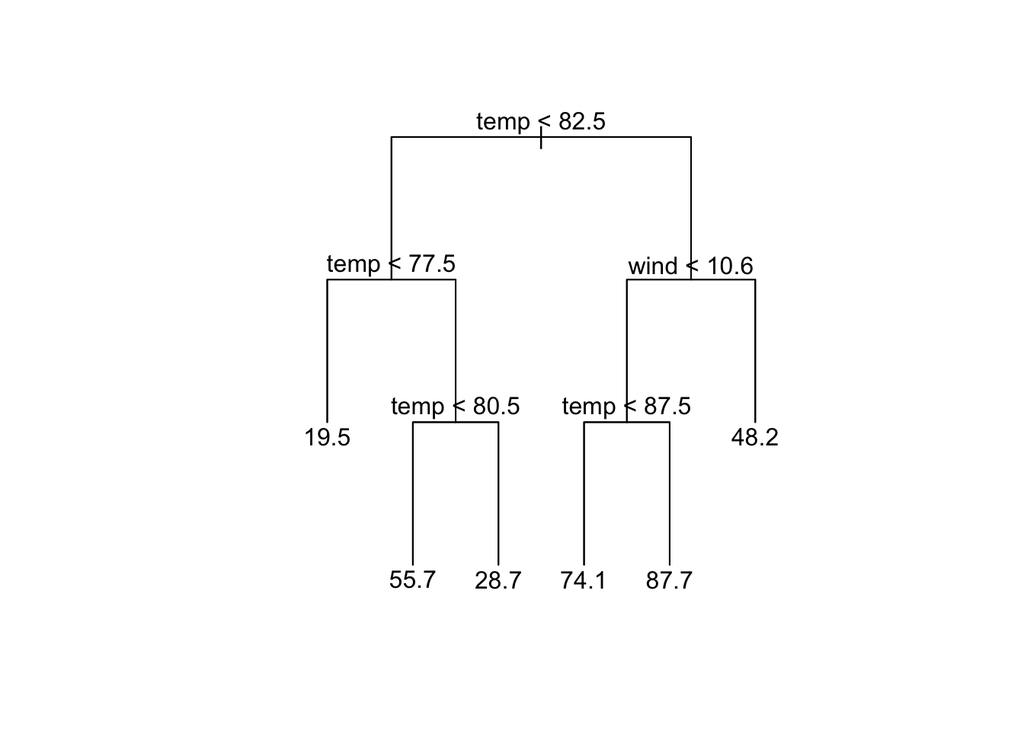

```r
summary(ozone.tree)
```

```
##
## Regression tree:
## tree(formula = ozone ~ temp + wind, data = ozone.train)
## Number of terminal nodes:  6
## Residual mean deviance:  286 = 19800 / 69
## Distribution of residuals:
##    Min. 1st Qu.  Median    Mean 3rd Qu.    Max.
##  -35.70   -9.33   -1.50    0.00    5.19   60.90
```

We see that `temperature` is the “most important”" predictor for predicting the ozone concentration. Observe that we can split on the same variable several times.

Now, we focus on the regions $R_j$, $j=1,\ldots, J$. What is $J$ here? Answer: $J=6$ (= the number of leaf nodes).

Below we see the partition of the `ozone` data set given in the `ozone.tree`, where the ozone levels have been color-coded, where a darker color corresponds to a higher ozone concentration. Each rectangle corresponds to one leaf node. Each number corresponding to a leaf node has been found by taking an average of all observations (in the training set) in the corresponding region (rectangle). Each line corresponds to an internal node, a binary partition of the predictor space.

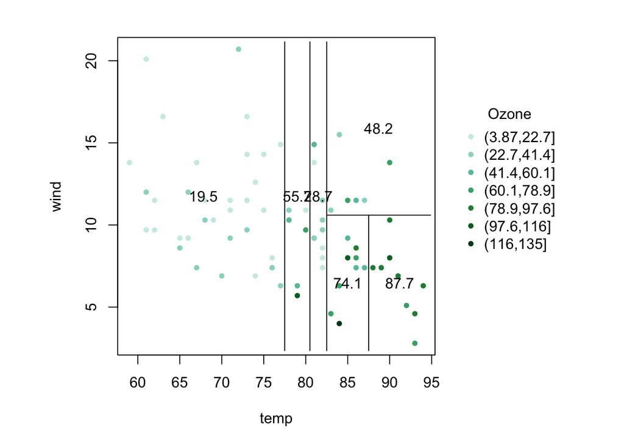

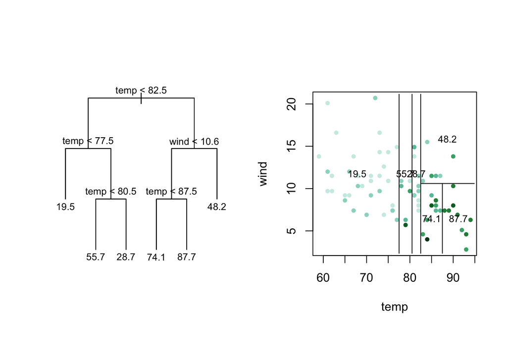

```r
par(pty = "s")
# o.class = cut(myozone$ozone, breaks= 7)
o.class = cut(ozone.train$ozone, breaks = 7)
col.oz = brewer.pal(9, "BuGn")
palette(col.oz[3:9])
par(mar = c(5.1, 4.1, 2.1, 8.1), xpd = TRUE)
plot(wind ~ temp, col = o.class, data = ozone.train, pch = 20)
partition.tree(ozone.tree, add = TRUE)
legend("topright", inset = c(-0.4, 0.2), title = "Ozone", legend = levels(o.class),
    col = col.oz[3:9], pch = 20, box.col = NA)
```

**Q:**

- Explain the connection between the tree and the region plot.
- Why is recursive binary splitting classified as a greedy algorithm?
- Discuss the advantages and disadvantages of letting each single split depend on only one of the predictors.
- Does our tree automatically include interactions between variables?

**A:**

- Each leaft node correspons to one region with prediction $\hat{y}_{R_j}$
- Recursive splitting does not necessarily give the optimal global solution, but will give the best solution at each split (given what is done previously).
- If the true connection between the response onzone and temperature and wind was so that splits should have been made on the diagonal of the temperature and wind space, that would take many splits on each of temperature and wind to produce. (See more below where we ask the same question for the classification setting.)
- Yes, we may have different effect of wind for different values of temperature.

## Tree performance

To test the predictive performance of our regression tree, we have randomly divided our observations into a test and a training set (here 1/3 test).

```r
ozone.pred = predict(ozone.tree, newdata = ozone.test)
ozone.MSE = mean((ozone.pred - ozone.test$ozone)^2)
ozone.MSE
```

```
## [1] 770.968
```

## R: function `tree` in library `tree`

by Brian D. Ripley: Fit a Classification or Regression Tree

Description: A tree is grown by binary recursive partitioning using the response in the specified formula and choosing splits from the terms of the right-hand-side.

tree(formula, data, weights, subset, na.action = na.pass, control = tree.control(nobs, …), method = “recursive.partition”, split = c(“deviance”, “gini”), model = FALSE, x = FALSE, y = TRUE, wts = TRUE, …)

- Details: A tree is grown by binary recursive partitioning using the response in the specified formula and choosing splits from the terms of the right-hand-side. Numeric variables are divided into X < a and X > a; the levels of an unordered factor are divided into two non-empty groups. The split which maximizes the reduction in impurity is chosen, the data set split and the process repeated. Splitting continues until the terminal nodes are too small or too few to be split.
- A numerical response gives regression while a factor response gives classifiation.
- The default choice for a function to minimize is the deviance, and for normal data (as we may assume for regression), the deviance is proportional to the RSS. For the interested reader, this is the connection between the deviance and the RSS for regression https://www.math.ntnu.no/emner/TMA4315/2018h/2MLR.html#deviance
- Tree growth is limited to a depth of 31 by the use of integers to label nodes.
- Factor predictor variables can have up to 32 levels. This limit is imposed for ease of labelling, but since their use in a classification tree with three or more levels in a response involves a search over 2^(k-1) - 1 groupings for k levels, the practical limit is much less.

A competing R function is `rpart`, explained in https://cran.r-project.org/web/packages/rpart/vignettes/longintro.pdf

## Classification trees

remember the minor head injury example?

Let $K$ be the number of classes for the response.

Building a decision tree in this setting is similar to building a regression tree for a quantitative response, but there are two main differences: *the prediction and the splitting criterion*

**1) The prediction:**

- In the regression case we use the mean value of the responses in $R_j$ as a prediction for an observation that falls into region $R_j$.
- For the classification case however, we have two possibilities:
  - Majority vote: Predict that the observation belongs to the most commonly occurring class of the training observations in $R_j$.
  - Estimate the probability that an observation $x_i$ belongs to a class $k$, $\hat{p}_{jk}(x_i)$, and then classify according to a threshold value. This estimated probability is the proportion of class $k$ training observations in region $R_j$, with $n_{jk}$ observations. Region $j$ has $N_j$ observations.
    $$\hat{p}_{jk} = \frac{1}{N_j} \sum_{i:x_i \in R_j} I(y_i = k)=\frac{n_{jk}}{N_j}.$$

**2) The splitting criterion:** We do not use RSS as a splitting criterion for a qualitative variable. Instead we can use some *measure of impurity* of the node. For leaf node $j$ and class $k=1,\ldots, K$:

Gini index:
$$G=\sum_{k=1}^K \hat{p}_{jk}(1-\hat{p}_{jk}),$$

Cross entropy:
$$D=-\sum_{k=1}^K \hat{p}_{jk}log\hat{p}_{jk}$$
Here $\hat{p}_{jk}$ is the proportion of training observation in region $j$ that are from class $k$. Remark: the deviance is a scaled version of the cross entropy. $-2\sum_{k=1}^K n_{jk} log\hat{p}_{jk}$ where $\hat{p}_{jk}=\frac{n_{jk}}{N_j}$

When making a split in our classification tree, we want to minimize the Gini index or the cross-entropy.

**Q**: Why these splitting criteria? Measure of impurity? How? See classnotes.

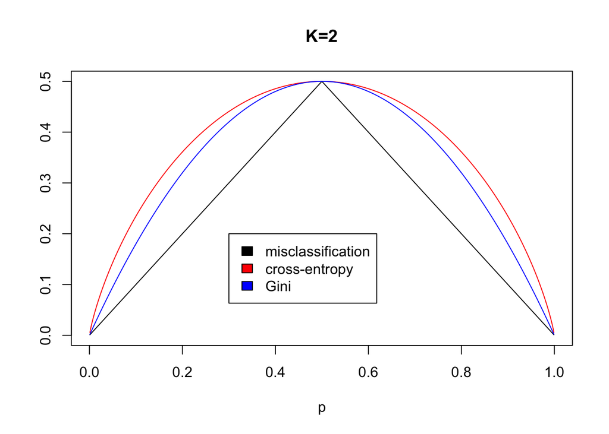

### Minor head injury - continued

```r
tree.HIClass = tree(clinically.important.brain.injury ~ ., data = headInjury2,
    subset = train, split = "deviance")
summary(tree.HIClass)
```

```
##
## Classification tree:
## tree(formula = clinically.important.brain.injury ~ ., data = headInjury2,
##     subset = train, split = "deviance")
## Variables actually used in tree construction:
## [1] "GCS.15"  "bskullf" "risk"    "age"     "GCS.13"
## Number of terminal nodes:  9
## Residual mean deviance:  0.66 = 555 / 841
## Misclassification error rate: 0.126 = 107 / 850
```

Deviance=$-2 \sum_{j}\sum_{k}n_{jk}log(\hat{p}_{jk})$ for all nodes $j$ and classes $k$. (Formula on page 255 of Venables and Ripley (2002).)

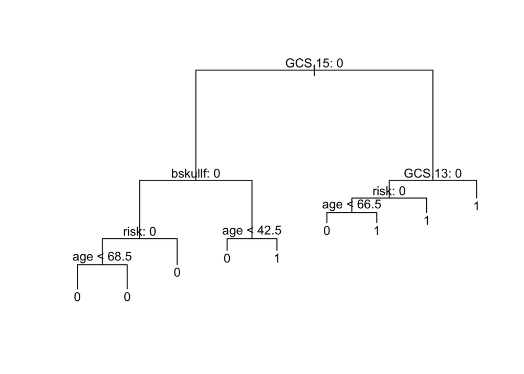

```r
plot(tree.HIClass, type = "proportional")
text(tree.HIClass, pretty = 1)
```

Length of branches are now proportional to the decrease in impurity.

### Minor head injury - with Gini index

```r
tree.HIClassG = tree(clinically.important.brain.injury ~ ., headInjury2,
    subset = train, split = "gini")
summary(tree.HIClassG)
```

```
##
## Classification tree:
## tree(formula = clinically.important.brain.injury ~ ., data = headInjury2,
##     subset = train, split = "gini")
## Variables actually used in tree construction:
## [1] "GCS.15"  "bskullf" "risk"    "age"     "oskullf" "vomit"   "amnesia"
## [8] "consc"   "GCS.13"
## Number of terminal nodes:  75
## Residual mean deviance:  0.52 = 403 / 775
## Misclassification error rate: 0.109 = 93 / 850
```

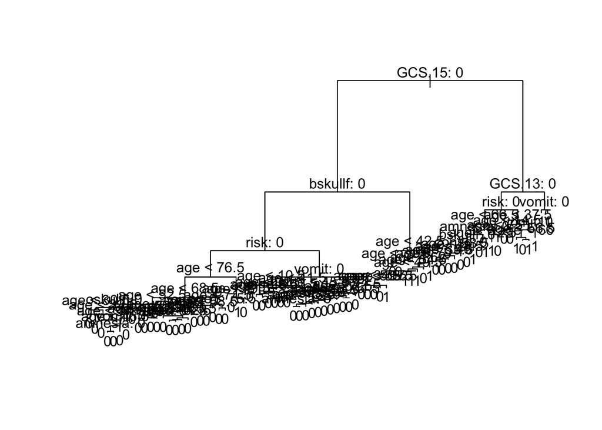

```r
tree.HIClassG = tree(clinically.important.brain.injury ~ ., headInjury2,
    subset = train, split = "gini")
plot(tree.HIClassG)
text(tree.HIClassG, pretty = 1)
```

We also use the classification tree to predict the status of the patients in the test set (the one grown with deviance)

```r
library(caret)
tree.pred = predict(tree.HIClass, headInjury2[test, ], type = "class")
confusionMatrix(tree.pred, reference = headInjury2[test, ]$clinically.important.brain.injury)
```

```
## Confusion Matrix and Statistics
##
##           Reference
## Prediction   0   1
##          0 356  42
##          1  24  49
##
##                Accuracy : 0.86
##                  95% CI : (0.825, 0.89)
##     No Information Rate : 0.807
##     P-Value [Acc > NIR] : 0.00155
##
##                   Kappa : 0.514
##
##  Mcnemar's Test P-Value : 0.03639
##
##             Sensitivity : 0.937
##             Specificity : 0.538
##          Pos Pred Value : 0.894
##          Neg Pred Value : 0.671
##              Prevalence : 0.807
##          Detection Rate : 0.756
##    Detection Prevalence : 0.845
##       Balanced Accuracy : 0.738
##
##        'Positive' Class : 0
##
```

And for the Gini-grown tree

```r
tree.predG = predict(tree.HIClassG, headInjury2[test, ], type = "class")
confusionMatrix(tree.predG, reference = headInjury2[test, ]$clinically.important.brain.injury)
```

```
## Confusion Matrix and Statistics
##
##           Reference
## Prediction   0   1
##          0 354  47
##          1  26  44
##
##                Accuracy : 0.845
##                  95% CI : (0.809, 0.877)
##     No Information Rate : 0.807
##     P-Value [Acc > NIR] : 0.0186
##
##                   Kappa : 0.455
##
##  Mcnemar's Test P-Value : 0.0192
##
##             Sensitivity : 0.932
##             Specificity : 0.484
##          Pos Pred Value : 0.883
##          Neg Pred Value : 0.629
##              Prevalence : 0.807
##          Detection Rate : 0.752
##    Detection Prevalence : 0.851
##       Balanced Accuracy : 0.708
##
##        'Positive' Class : 0
##
```

### Questions:

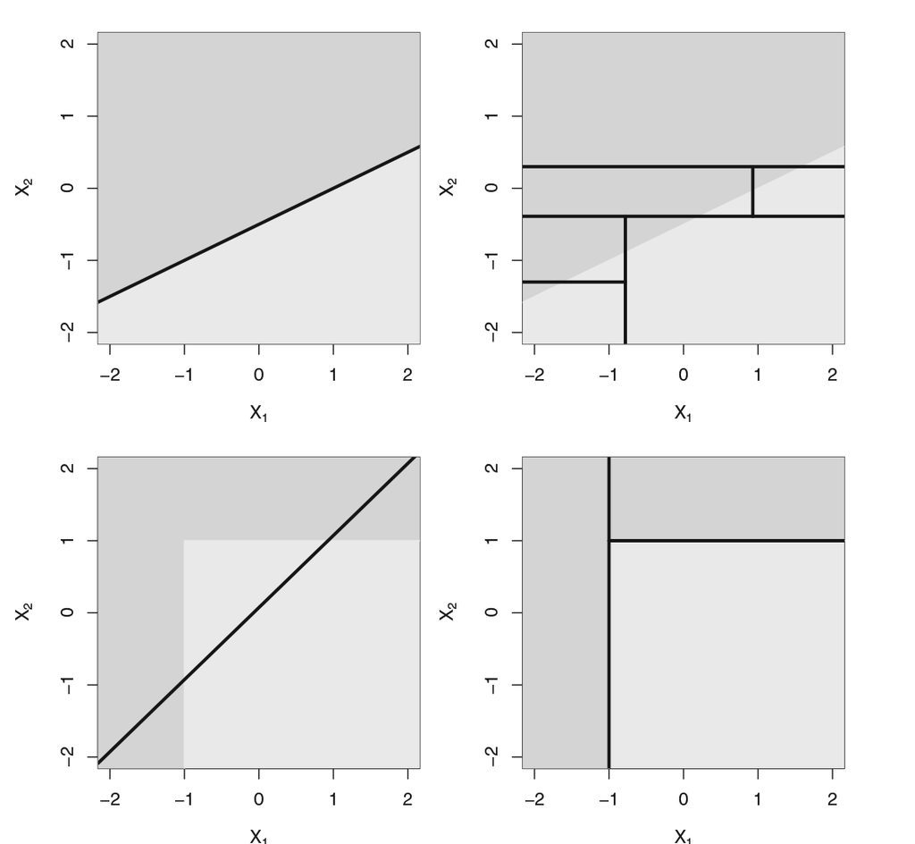

Linear boundary ISL Figure 8.7

- What about a rectangular boundary (figure above)?
- Study the above confusion matrices. One type of mistake is more severe than the other. Discuss if it is possible to change the algorithm in order to decrease the number of severe mistakes.

# Pruning

Imagine that we have a data set with many predictors, and that we fit a large tree. Then, the number of observations from the training set that falls into some of the regions $R_j$ may be small, and we may be concerned that we have overfitted the training data.

$Pruning$ is a technique for solving this problem.

By $pruning$ the tree we reduce the size or depth of the decision tree. When we reduce the number of terminal nodes and regions $R_1,...,R_J$, each region will probably contain more observations. This way we reduce the probability of overfitting, and we may get better predictions for test data.

If we have a large dataset with many explanatory variables and terminal nodes, we can also prune the tree if we want to create a simpler tree and increase the interpretability of the model.

In the classification tree (grown with deviance) we saw that we got several unnecessary splits. This is also something that can be avoided by pruning.

But, there are many possible pruned versions of our full tree. Can we investigate all of these?

## Cost complexity pruning

We can prune the tree by using a algorithm called *cost complexity pruning*. We first build a large tree $T_0$ by recursive binary splitting. Then we try to find a subtree $T\subset T_0$ that (for a given value of $\alpha$) minimizes

$$C_{\alpha}(T)=Q(T)+\alpha |T|,$$
where $Q(T)$ is our cost function, $|T|$ is the number of terminal nodes in tree $T$. The parameter $\alpha$ is then a parameter penalizing the number of terminal nodes, ensuring that the tree does not get too many branches.

We proceed by repeating the the process for the best subtree $T$, and this way we get a sequence of smaller of smaller subtrees where each tree is the best subtree of the previous tree.

For regression trees we choose $Q(T)=\sum_{m=1}^{|T|}\sum_{x_i\in R_m}(y_i - \hat{y}_{R_m})^2$, and or classification trees the entropy (deviance), Gini or misclassification rate.

Given a value of $\alpha$ we get a pruned tree (but the same pruned tree for ranges of $\alpha$).

For $\alpha=0$ we get $T_0$ and as $\alpha$ increases we get smaller and smaller trees.

Please study this [note from Bo Lindqvist in MA8701 in 2017 - Advanced topics in Statistical Learning and Inference](https://www.math.ntnu.no/emner/TMA4268/2018v/notes/CART1MA87012017BoLindqvist.pdf) for an example of how we perform cost complexity pruning in detail. Alterntively, this method, with proofs, are given in Ripley (1996), Section 7.2.

## Building a regression (classification) tree: Algorithm 8.1

1. Use recursive binary splitting to grow a large tree on the training data, stopping only when each terminal node has fewer than some minimum number of observations.
2. Apply cost complexity pruning to the large tree in order to obtain a sequence of best subtrees, as a function of $\alpha$.
3. Use K-fold cross-validation to choose $\alpha$. That is, divide the training observations into K folds. For each k = $1,\ldots, K$:
   - Repeat Steps 1 and 2 on all but the kth fold of the training data.
   - Evaluate the mean squared prediction (misclassification, gini, cross-entropy) error on the data in the left-out kth fold, as a function of $\alpha$.
   - Average the results for each value of $\alpha$, and pick $\alpha$ to minimize the average error.
4. Return the subtree from Step 2 that corresponds to the chosen value of $\alpha$.